# Activity: Popular Names

Hanbyeol Lee

6/3/2024

# Activity

**Goal**: By the end of the activity, each team will create a graph showing ups and downs in the popularity of four names according to the U.S. social security administration

### Step 1

```r
glimpse(BabyNames)
```

```
Rows: 1,792,091
Columns: 4
$ name  <chr> "Mary", "Anna", "Emma", "Elizabeth", "Minnie", "Margaret", "Ida", "Alice", "Bertha", "Sarah", "Annie", "Clara", "Ella", "Florence", "Cora", "Martha", "Laura", "Ne…
$ sex   <chr> "F", "F", "F", "F", "F", "F", "F", "F", "F", "F", "F", "F", "F", "F", "F", "F", "F", "F", "F", "F", "F", "F", "F", "F", "F", "F", "F", "F", "F", "F", "F", "F", "F…
$ count <int> 7065, 2604, 2003, 1939, 1746, 1578, 1472, 1414, 1320, 1288, 1258, 1226, 1156, 1063, 1045, 1040, 1012, 995, 982, 949, 858, 808, 796, 793, 787, 783, 769, 768, 704, …
$ year  <int> 1880, 1880, 1880, 1880, 1880, 1880, 1880, 1880, 1880, 1880, 1880, 1880, 1880, 1880, 1880, 1880, 1880, 1880, 1880, 1880, 1880, 1880, 1880, 1880, 1880, 1880, 1880, …
```

### Step 2

The goal is to create a graph showing the popularity trends of two male and two female names over time.

### Step 3

All variable (‘name’, ‘sex’, ‘count’,‘year’) will be used in the graph. There will be no variables will be excluded from the graph.

- ‘year’ will be used an x-axis
- ‘name’ will be used to differentiate lines.
- ‘count’ will be used an y-axis to represent the popularity (total number of occurences) of each name. It might be aggregated if there were multiple entries for the same name and year combination.
- ‘sex’ will be used to color the lines in the graph to differentiate between male and female names.

### Step 4

- Cases might be filtered to include only the chosen names.
- Cases will be grouped by year, name, and sex, and the total occurrences will be summed.
- The dataset will be filtered to include only the years of interest.

### Step 5

1. Filter the dataset to include only the chosen male and female names.
2. Group the data by year, name, and sex.
3. Summarize the total number of occurrences for each name by year and gender.
4. Filter the dataset to include only the relevant years.

### Step 7: modify the starter code given in the book to produce your own R code..

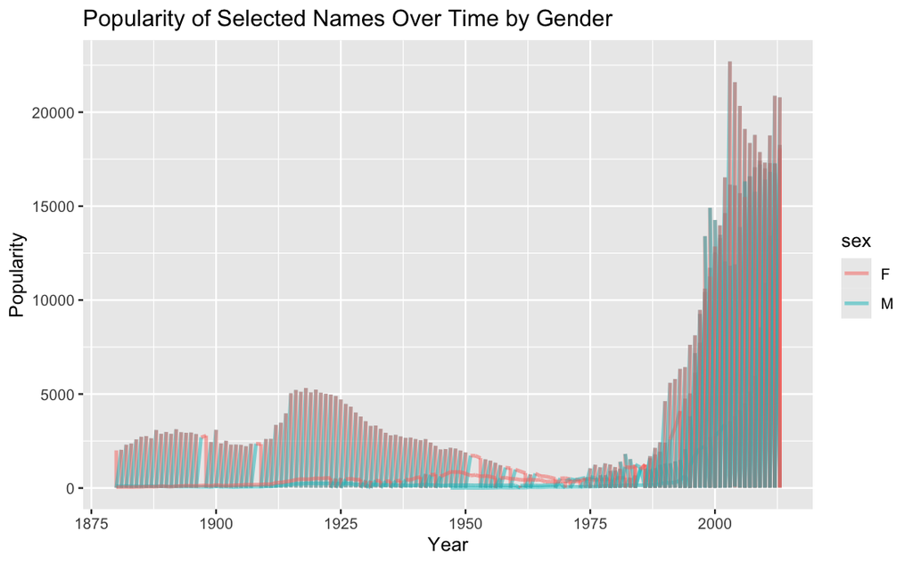

```r
glyph_ready_data %>%
  ggplot(aes(x = year, y = count, group = name)) +
  geom_line(size = 1, alpha = 0.5, aes(color = sex)) +
  ylab("Popularity") + xlab("Year") +
  ggtitle("Popularity of Selected Names Over Time by Gender")
```